# Rapport expert: Prédiction du nombre de sinistres pour assurance responsabilité civile automobile

# 1 Introduction

# 2 Analyse des données

## 2.1 Importation des données

On commençe par importer nos jeux de données `train` et `test`. Puis on affiche le `train` afin d’observer l’allure des données.

```r
# Téléchargement du jeu de données
train<-read.csv('./data/train_set.csv', header = T, sep = ",",dec=".")
test<-read.csv('./data/test_set.csv', header = T, sep = ",",dec=".")
set.seed(2025)

# Affichage du jeu de données sous forme de tableau
rmarkdown::paged_table(train)
```

| PolID | Claim | Period_Exp | Car_Power | Car_Age | Age | Bonus_Malus | Car_Model | Car_Fuel | Urban_rural_class | Inhab_density | French_region |
| --- | --- | --- | --- | --- | --- | --- | --- | --- | --- | --- | --- |
| 54009 | 4 | 0.560000000 | 4 | 4 | 46 | 50 | B4 | Diesel | A | 29 | Centre |
| 93954 | 5 | 1.000000000 | 7 | 9 | 67 | 50 | B2 | Diesel | E | 4762 | Provence-Alpes-Cotes-D'Azur |
| 2239279 | 8 | 0.410000000 | 4 | 12 | 52 | 50 | B1 | Regular | D | 824 | Languedoc-Roussillon |
| 3016883 | 4 | 0.270000000 | 5 | 9 | 23 | 90 | B3 | Diesel | E | 6924 | Ile-de-France |
| 3253234 | 11 | 0.080000000 | 4 | 13 | 53 | 50 | B1 | Regular | D | 824 | Languedoc-Roussillon |
| 4031494 | 4 | 0.100000000 | 4 | 1 | 31 | 85 | B12 | Regular | E | 2983 | Nord-Pas-de-Calais |
| 1198596 | 0 | 0.960000000 | 14 | 25 | 49 | 50 | B10 | Regular | E | 5053 | Ile-de-France |
| 1106349 | 0 | 0.730000000 | 10 | 2 | 38 | 51 | B12 | Diesel | C | 160 | Poitou-Charentes |
| 1085946 | 0 | 0.090000000 | 4 | 12 | 27 | 68 | B5 | Regular | C | 229 | Bretagne |
| 2079592 | 0 | 0.730000000 | 5 | 4 | 32 | 50 | B3 | Diesel | C | 461 | Bretagne |

[output cut: 9990 more lines]

Ensuite on affiche un tableau affichant le nom de chaque variable avec son type et le nombre de valeurs manquantes pour chacune d’entre elles.

```r
variable_summary <- data.frame(
  Type = sapply(train, class),
  Missing_Values = sapply(train, function(x) sum(is.na(x))))

variable_summary %>%
  kable(format = "html", caption = "Résumé des variables") %>%
  kable_styling(bootstrap_options = c("striped", "hover", "condensed", "responsive"))
```

Table 2.1: Résumé des variables

|  | Type | Missing_Values |
| --- | --- | --- |
| PolID | numeric | 0 |
| Claim | integer | 0 |
| Period_Exp | numeric | 0 |
| Car_Power | integer | 0 |
| Car_Age | integer | 0 |
| Age | integer | 0 |
| Bonus_Malus | integer | 0 |
| Car_Model | character | 0 |
| Car_Fuel | character | 0 |
| Urban_rural_class | character | 0 |
| Inhab_density | integer | 0 |
| French_region | character | 0 |

On remarque qu’il n’ y a aucune valeurs manquantes.

```r
summary(train)
```

```
##      PolID             Claim            Period_Exp         Car_Power
##  Min.   :      3   Min.   : 0.00000   Min.   :0.002732   Min.   : 4.000
##  1st Qu.:1157434   1st Qu.: 0.00000   1st Qu.:0.170000   1st Qu.: 5.000
##  Median :2271910   Median : 0.00000   Median :0.490000   Median : 6.000
##  Mean   :2620755   Mean   : 0.03894   Mean   :0.528595   Mean   : 6.454
##  3rd Qu.:4046150   3rd Qu.: 0.00000   3rd Qu.:0.990000   3rd Qu.: 7.000
##  Max.   :6114330   Max.   :11.00000   Max.   :2.010000   Max.   :15.000
##     Car_Age             Age          Bonus_Malus      Car_Model
##  Min.   :  0.000   Min.   : 18.00   Min.   : 50.00   Length:542389
##  1st Qu.:  2.000   1st Qu.: 34.00   1st Qu.: 50.00   Class :character
##  Median :  6.000   Median : 44.00   Median : 50.00   Mode  :character
##  Mean   :  7.036   Mean   : 45.49   Mean   : 59.77
##  3rd Qu.: 11.000   3rd Qu.: 55.00   3rd Qu.: 64.00
##  Max.   :100.000   Max.   :100.00   Max.   :228.00
##    Car_Fuel         Urban_rural_class  Inhab_density   French_region
##  Length:542389      Length:542389      Min.   :    1   Length:542389
##  Class :character   Class :character   1st Qu.:   92   Class :character
##  Mode  :character   Mode  :character   Median :  393   Mode  :character
##                                        Mean   : 1793
##                                        3rd Qu.: 1658
##                                        Max.   :27000
```

## 2.2 Observations et transformation des données

```r
#Supprimer la variable PolID
train<-train %>% select(-PolID)
test<-test %>% select(-PolID)
```

```r
numeric_cols <- c("Claim", "Period_Exp", "Car_Power", "Car_Age", "Age", "Bonus_Malus", "Inhab_density")
categorical_cols <- c("Car_Model", "Car_Fuel", "Urban_rural_class", "French_region")
```

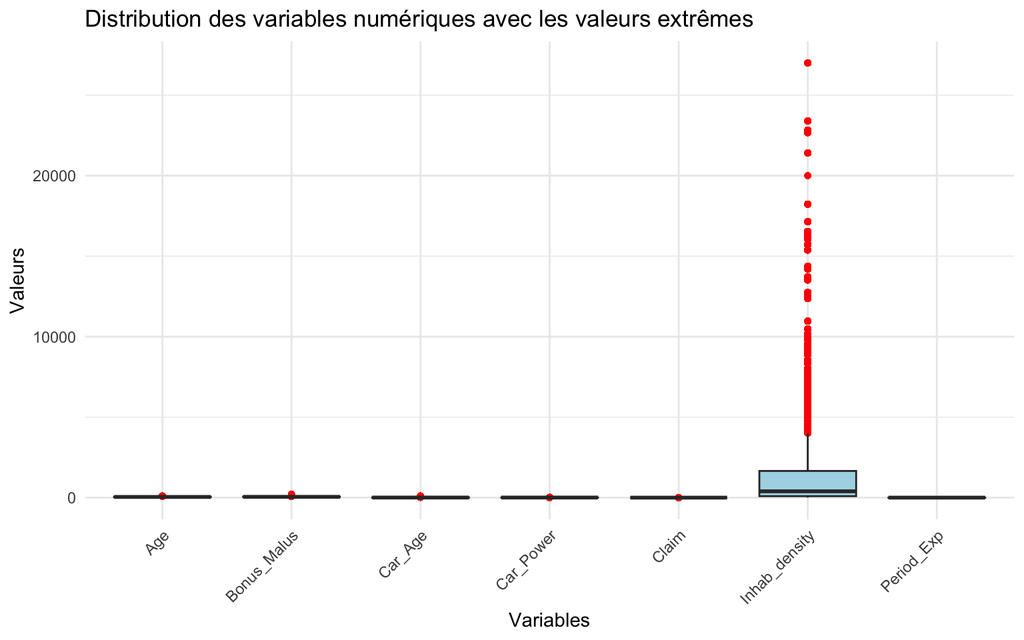

```r
# Transformation des données au format long pour ggplot2
train_long <- train %>%
  select(all_of(numeric_cols)) %>%
  pivot_longer(cols = everything(), names_to = "Variable", values_to = "Valeur")

# Création des boxplots
ggplot(train_long, aes(x = Variable, y = Valeur)) +
  geom_boxplot(fill = "lightblue", outlier.color = "red", outlier.shape = 16) +
  theme_minimal() +
  theme(axis.text.x = element_text(angle = 45, hjust = 1)) +
  labs(title = "Distribution des variables numériques avec les valeurs extrêmes",
       x = "Variables", y = "Valeurs")
```

```r
# Nombre de catégories par variable
cat_counts <- sapply(train[categorical_cols], function(x) length(unique(x)))

# Affichage des résultats
print(cat_counts)
```

```
##         Car_Model          Car_Fuel Urban_rural_class     French_region
##                11                 2                 6                22
```

```r
# Transformer les variables catégorielles en facteurs
train$Car_Model <- as.factor(train$Car_Model)
train$Car_Fuel <- as.factor(train$Car_Fuel)
train$Urban_rural_class <- as.factor(train$Urban_rural_class)
train$French_region <- as.factor(train$French_region)
train$Bonus_Malus <- as.factor (train$Bonus_Malus)
```

```r
#Transformer la variable Bonus_Malus en variables binaire
#train$Bonus_Malus <- ifelse(train$Bonus_Malus < 100, "Bonus", "Malus")
#test$Bonus_Malus <- ifelse(test$Bonus_Malus < 100, "Bonus", "Malus")
```

```r
summary(train)
```

```
##      Claim            Period_Exp         Car_Power         Car_Age
##  Min.   : 0.00000   Min.   :0.002732   Min.   : 4.000   Min.   :  0.000
##  1st Qu.: 0.00000   1st Qu.:0.170000   1st Qu.: 5.000   1st Qu.:  2.000
##  Median : 0.00000   Median :0.490000   Median : 6.000   Median :  6.000
##  Mean   : 0.03894   Mean   :0.528595   Mean   : 6.454   Mean   :  7.036
##  3rd Qu.: 0.00000   3rd Qu.:0.990000   3rd Qu.: 7.000   3rd Qu.: 11.000
##  Max.   :11.00000   Max.   :2.010000   Max.   :15.000   Max.   :100.000
##
##       Age          Bonus_Malus       Car_Model         Car_Fuel
##  Min.   : 18.00   50     :307112   B12    :133017   Diesel :265864
##  1st Qu.: 34.00   100    : 15599   B1     :130223   Regular:276525
##  Median : 44.00   68     : 15059   B2     :127716
##  Mean   : 45.49   72     : 14941   B3     : 42704
##  3rd Qu.: 55.00   76     : 14617   B5     : 27741
##  Max.   :100.00   64     : 14610   B6     : 22946
##                   (Other):160451   (Other): 58042
##  Urban_rural_class Inhab_density                       French_region
##  A: 83048          Min.   :    1   Centre                     :128386
##  B: 60424          1st Qu.:   92   Rhone-Alpes                : 67777
##  C:153471          Median :  393   Provence-Alpes-Cotes-D'Azur: 63429
##  D:121319          Mean   : 1793   Ile-de-France              : 55942
##  E:109708          3rd Qu.: 1658   Bretagne                   : 33611
##  F: 14419          Max.   :27000   Pays-de-la-Loire           : 31062
##                                    (Other)                    :162182
```

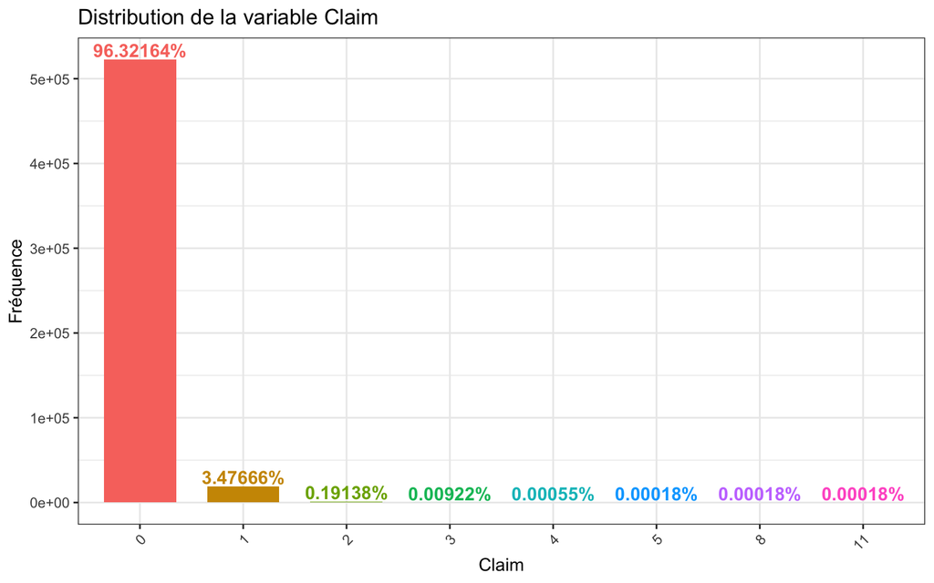

```r
# Distribution de la variable cible
plot_percentage(train,"Claim",5)
```

La distribution de la variable cible `Claim` montre un fort déséquilibre dans les données. En effet, 96.32% des contrats n’ont enregistré aucun sinistre, tandis que seulement 3.48% en comptent un, et les cas avec deux sinistres ou plus sont extrêmement rares (moins de 0.2%). Ce désiquilibre pose un défi en modélisation. Un modèle classique risque d’être biaisé en faveur des prédictions nulles, réduisant ainsi sa capacité à identifier les cas de sinistre.

Plusieurs stratégies peuvent alors être envisagées. On pourrait utiliser un modèle de comptage, comme une régression de Poisson ou une régression binomiale négative, qui sont adaptées aux variables discrètes et asymétriques. D’autre part, une approche basée sur le rééchantillonnage (sous-échantillonnage des contrats sans sinistre ou sur-échantillonnage des sinistres) pourrait améliorer l’apprentissage du modèle. Une autre alternative serait de transformer le problème en classification binaire (sinistre vs. pas de sinistre) avec une régression logistique.

## 2.3 Corrélation entre les variables

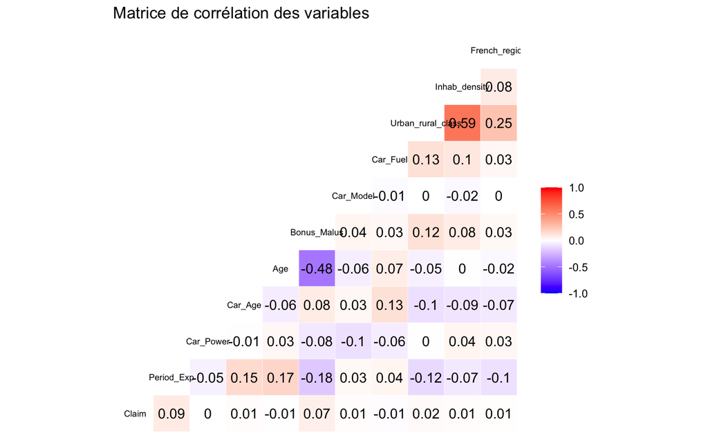

```r
# Convertir les variables catégorielles en nombres
train$Bonus_Malus <- as.numeric(as.factor(train$Bonus_Malus))
train$Car_Model <- as.numeric(as.factor(train$Car_Model))
train$Car_Fuel <- as.numeric(as.factor(train$Car_Fuel))
train$Urban_rural_class <- as.numeric(as.factor(train$Urban_rural_class))
train$French_region <- as.numeric(as.factor(train$French_region))

ggcorr(train, label = TRUE, label_round = 2, low = "blue", mid = "white", high = "red", size = 2.5) +
  ggtitle("Matrice de corrélation des variables") +
  theme(axis.text.x = element_text(angle = 40, hjust = 0,5, size = 3),  # Rotation + réduction taille
        axis.text.y = element_text(size = 2))  # Taille réduite sur l'axe Y
```

Après analyse de la matrice, on remarque une corrélation négative entre l’âge du conducteur `Age` et le coefficient `Bonus_Malus` (-0.48) est significative. Elle traduit le fait que les conducteurs plus jeunes ont tendance à accumuler plus de malus, tandis que les conducteurs plus expérimentés bénéficient d’un bonus. Une autre relation forte apparaît entre la densité d’habitants `Inhab_density` et la classe urbaine `Urban_rural_class` (0.59), confirmant que les zones urbaines ont une densité de population plus élevée.

La variable cible `Claim` (nombre de sinistres) n’entretient que de faibles corrélations avec les autres variables. Par exemple, la période d’exposition `Period_Exp` est légèrement corrélée avec le nombre de sinistres (0.09), ce qui est intuitif : plus une assurance est active longtemps, plus elle a de chances d’être associée à un sinistre. Cependant, les autres variables, comme l’âge du conducteur, la puissance du véhicule `Car_Power` ou le type de carburant `Car_Fuel`, montrent des relations très faibles avec `Claim`, montrant que ces facteurs seuls n’expliquent pas directement la survenue des sinistres.

```r
train
```

```
##      Claim  Period_Exp Car_Power Car_Age Age Bonus_Malus Car_Model Car_Fuel
## 1        4 0.560000000         4       4  46           1         9        1
## 2        5 1.000000000         7       9  67           1         7        1
## 3        8 0.410000000         4      12  52           1         1        2
## 4        4 0.270000000         5       9  23          41         8        1
## 5       11 0.080000000         4      13  53           1         1        2
## 6        4 0.100000000         4       1  31          36         4        2
## 7        0 0.960000000        14      25  49           1         2        2
## 8        0 0.730000000        10       2  38           2         4        1
## 9        0 0.090000000         4      12  27          19        10        2
## 10       0 0.730000000         5       4  32           1         8        1
## 11       0 0.040000000         5       4  22          36         4        2
## 12       0 0.020000000         7       1  36           4         4        1
## 13       0 0.780000000         6       2  40           4         4        1
## 14       0 0.440000000         6       9  69           1         7        1
```

[output cut: 18168 more lines]

# 3 Modèle Régression de Poisson

```r
# Calcul de la moyenne et de la variance de Claim
mean_claim <- mean(train$Claim)
var_claim <- var(train$Claim)

cat("Moyenne de Claim :", mean_claim, "\n")
```

```
## Moyenne de Claim : 0.038937
```

```r
cat("Variance de Claim :", var_claim, "\n")
```

```
## Variance de Claim : 0.04221091
```

L’analyse des caractéristiques de la variable cible Claim montre que sa moyenne (0.0389) et sa variance (0.0422) sont très proches, ce qui est un bon indicateur de l’adéquation avec une distribution de Poisson.

```r
# Ajustement du modèle de Poisson
poisson_model <- glm(Claim ~ ., data = train, family = poisson(link = "log"))

# Résumé des coefficients du modèle
summary(poisson_model)
```

```
##
## Call:
## glm(formula = Claim ~ ., family = poisson(link = "log"), data = train)
##
## Coefficients:
##                     Estimate Std. Error  z value Pr(>|z|)
## (Intercept)       -5.242e+00  4.997e-02 -104.907  < 2e-16 ***
## Period_Exp         1.609e+00  2.155e-02   74.672  < 2e-16 ***
## Car_Power          3.244e-02  3.430e-03    9.459  < 2e-16 ***
## Car_Age           -5.939e-03  1.290e-03   -4.605 4.13e-06 ***
## Age                6.690e-03  5.240e-04   12.768  < 2e-16 ***
## Bonus_Malus        2.630e-02  3.997e-04   65.804  < 2e-16 ***
## Car_Model          1.070e-02  2.207e-03    4.849 1.24e-06 ***
## Car_Fuel          -1.818e-01  1.410e-02  -12.900  < 2e-16 ***
## Urban_rural_class  9.669e-02  6.614e-03   14.619  < 2e-16 ***
## Inhab_density     -4.448e-06  2.053e-06   -2.167   0.0302 *
## French_region      6.929e-03  1.091e-03    6.350 2.15e-10 ***
## ---
## Signif. codes:  0 '***' 0.001 '**' 0.01 '*' 0.05 '.' 0.1 ' ' 1
##
## (Dispersion parameter for poisson family taken to be 1)
##
##     Null deviance: 140439  on 542388  degrees of freedom
## Residual deviance: 131398  on 542378  degrees of freedom
## AIC: 172018
##
## Number of Fisher Scoring iterations: 6
```

```r
dispersion <- sum(residuals(poisson_model, type = "pearson")^2) / poisson_model$df.residual
cat("Indice de dispersion :", dispersion, "\n")
```

```
## Indice de dispersion : 1.091223
```

```r
set.seed(42)

# Création de l'index pour séparer les données (80% train, 20% test)
trainIndex <- createDataPartition(train$Claim, p = 0.8, list = FALSE)

# Création des datasets train et test
train_set <- train[trainIndex, ]
test_set  <- train[-trainIndex, ]

# Vérification des dimensions
cat("Taille du dataset d'entraînement :", nrow(train_set), "\n")
```

```
## Taille du dataset d'entraînement : 433912
```

```r
cat("Taille du dataset de test :", nrow(test_set), "\n")
```

```
## Taille du dataset de test : 108477
```